# SpaceMix Vignette

Gideon Bradburd

2016-02-20

# Introduction

SpaceMix is a statistical method that uses genome-wide polymorphism data to build “geogenetic maps,” in which the distances between samples reflect genetic, rather than geographic, distance. In the underlying model, allele frequency covariance is a decreasing function of geogenetic distance, and nonlocal gene flow such as admixture can be identified as anomalously strong covariance over long distances. This admixture is explicitly co-estimated and depicted as arrows, from the source of admixture to the recipient, on the geogenetic map.

This vignette will guide you through using the R package SpaceMix. The vignette is organized into three sections:

1. Formatting Data
2. Running a SpaceMix analysis
3. Visualizing results

# Formatting Data

There are three different types of data that can be used to initiate a SpaceMix analysis. Below, we walk through each data type and how to format it for analysis.

## Using allele count data

We assume that the data are bi-allelic SNPs genotyped at *L* loci in *K* samples, where each sample consists of at least one genotyped individual. At each locus, the user should pick, at random, an allele to count, and then summarize the genotype data as the number of times that allele is observed at that locus in each sample. This process is illustrated below:

Our samples consist of 5 individuals. Their genotype data at a single locus are as follows:

Genotype data for a single locus

| Sample | Genotype |
| --- | --- |
| Ind1 | AA |
| Ind2 | AT |
| Ind3 | TT |
| Ind4 | TA |
| Ind5 | NN |

Notice that Ind5 was not successfully genotyped at this locus. Now, if we choose to count the ‘T’ allele, we can summarize these genotype data by simply counting the number of ‘T’ alleles in each individual’s genotype.

Allele count data at a single locus

| Sample | Genotype |
| --- | --- |
| Ind1 | 0 |
| Ind2 | 1 |
| Ind3 | 2 |
| Ind4 | 1 |
| Ind5 | 0 |

We will refer to these data as allele count data, or *C<sub>lk</sub>*, in which the subscript *l* indexes the locus (a column in the genotype matrix) and the subscript *k* indexes the sample (a row in the genotype matrix).  
Notice that Ind5, which was not genotyped at this locus, has an allele count of 0.

The user must also specify a matrix of sample sizes, which we refer to as *S<sub>lk</sub>*. In this matrix, the *lk*<sup>th</sup> entry gives the number of chromosomes genotyped at locus *l* in sample *k*. Using the example dataset above, assuming each individual is diploid, the corresponding sample size entries are:

Sample size data at a single locus

| Sample | Sample Size |
| --- | --- |
| Ind1 | 2 |
| Ind2 | 2 |
| Ind3 | 2 |
| Ind4 | 2 |
| Ind5 | 0 |

Notice that the missing data at this locus in Ind5 is denoted by a sample size of 0, as 0  
chromosomes were successfully genotyped at this locus.

This process of counting a randomly chosen allele at each locus and summarizing the genotype data as allele counts should be repeated for each locus in the dataset.

To extend our example, imagine that our dataset consists of the same 5 individuals genotyped at 10 loci:

Genotype matrix

| Sample | Locus1 | Locus2 | Locus3 | Locus4 | Locus5 | Locus6 | Locus7 | Locus8 | Locus9 | Locus10 |
| --- | --- | --- | --- | --- | --- | --- | --- | --- | --- | --- |
| Ind1 | AA | AC | GG | CT | AT | NN | NN | AA | GC | AG |
| Ind2 | AT | AC | CG | CC | AT | GG | TC | NN | GC | GA |
| Ind3 | TT | AA | NN | TT | AA | TG | CT | AA | GC | GG |
| Ind4 | TA | CC | GG | TT | NN | TG | TT | AG | GG | GG |
| Ind5 | NN | CC | CG | CT | TT | TG | CC | GG | GC | AA |

We randomly choose to sample the following alleles at each locus:

Counted alleles

| Locus1 | Locus2 | Locus3 | Locus4 | Locus5 | Locus6 | Locus7 | Locus8 | Locus9 | Locus10 |
| --- | --- | --- | --- | --- | --- | --- | --- | --- | --- |
| T | A | G | C | A | T | C | A | G | G |

Then, our allele counts matrix, *C<sub>lk</sub>*, will look like this:

Allele counts matrix, *C<sub>lk</sub>*

| Sample | Locus1 | Locus2 | Locus3 | Locus4 | Locus5 | Locus6 | Locus7 | Locus8 | Locus9 | Locus10 |
| --- | --- | --- | --- | --- | --- | --- | --- | --- | --- | --- |
| Ind1 | 0 | 1 | 2 | 1 | 1 | 0 | 0 | 2 | 1 | 1 |
| Ind2 | 1 | 1 | 1 | 2 | 1 | 0 | 1 | 0 | 1 | 1 |
| Ind3 | 2 | 2 | 0 | 0 | 2 | 1 | 1 | 2 | 1 | 2 |
| Ind4 | 1 | 0 | 2 | 0 | 0 | 1 | 0 | 1 | 2 | 2 |
| Ind5 | 0 | 0 | 1 | 1 | 0 | 1 | 2 | 0 | 1 | 0 |

And our sample size matrix, *S<sub>lk</sub>*, will look like this:

Sample size matrix, *S<sub>lk</sub>*, where 0 denotes missing data

| Sample | Locus1 | Locus2 | Locus3 | Locus4 | Locus5 | Locus6 | Locus7 | Locus8 | Locus9 | Locus10 |
| --- | --- | --- | --- | --- | --- | --- | --- | --- | --- | --- |
| Ind1 | 2 | 2 | 2 | 2 | 2 | 0 | 0 | 2 | 2 | 2 |
| Ind2 | 2 | 2 | 2 | 2 | 2 | 2 | 2 | 0 | 2 | 2 |
| Ind3 | 2 | 2 | 0 | 2 | 2 | 2 | 2 | 2 | 2 | 2 |
| Ind4 | 2 | 2 | 2 | 2 | 0 | 2 | 2 | 2 | 2 | 2 |
| Ind5 | 0 | 2 | 2 | 2 | 2 | 2 | 2 | 2 | 2 | 2 |

These matrices should be in R and of class `matrix`, rather than of class `data.frame`. There is an example dataset in the SpaceMix package with L = 10000 and K = 30, and you can take a look at it with

```r
# load the example dataset and look at its elements
require(SpaceMix)
data(spacemix.example.dataset)
str(spacemix.example.dataset)
```

```
## List of 3
##  $ allele.counts         : num [1:30, 1:10000] 3 4 2 2 3 7 2 5 3 7 ...
##  $ sample.sizes          : num [1:30, 1:10000] 10 10 10 10 10 10 10 10 10 10 ...
##  $ population.coordinates: num [1:30, 1:2] 1 1 1 1 1 3 3 3 3 3 ...
```

```r
# look at the attributes of the allele counts matrix
dim(spacemix.example.dataset$allele.counts)
```

```
## [1]    30 10000
```

```r
class(spacemix.example.dataset$allele.counts)
```

```
## [1] "matrix"
```

```r
# look at the first 10 loci
spacemix.example.dataset$allele.counts[1:30,1:10]
```

```
##       [,1] [,2] [,3] [,4] [,5] [,6] [,7] [,8] [,9] [,10]
##  [1,]    3    0    0    0    0    0    0    0    0     0
##  [2,]    4    0    1    0    0    0    1    1    0     0
##  [3,]    2    2    0    1    0    1    0    0    0     0
##  [4,]    2    1    1    0    0    0    1    0    0     0
##  [5,]    3    0    1    5    0    0    0    0    0     0
##  [6,]    7    0    0    1    0    0    0    0    0     0
##  [7,]    2    0    1    0    0    0    0    0    0     0
##  [8,]    5    0    5    1    0    0    0    0    0     0
##  [9,]    3    0    0    1    0    0    0    0    0     0
## [10,]    7    0    0    0    1    0    0    0    0     0
## [11,]    3    0    0    1    0    0    0    2    3     0
## [12,]    3    0    1    5    0    0    0    0    0     0
## [13,]    3    0    1    1    0    0    0    0    0     0
## [14,]    2    0    0    0    0    0    0    0    0     0
```

[output cut: 16 more lines]

```r
spacemix.example.dataset$sample.sizes[1:30,1:10]
```

```
##       [,1] [,2] [,3] [,4] [,5] [,6] [,7] [,8] [,9] [,10]
##  [1,]   10   10   10   10   10   10   10   10   10    10
##  [2,]   10   10   10   10   10   10   10   10   10    10
##  [3,]   10   10   10   10   10   10   10   10   10    10
##  [4,]   10   10   10   10   10   10   10   10   10    10
##  [5,]   10   10   10   10   10   10   10   10   10    10
##  [6,]   10   10   10   10   10   10   10   10   10    10
##  [7,]   10   10   10   10   10   10   10   10   10    10
##  [8,]   10   10   10   10   10   10   10   10   10    10
##  [9,]   10   10   10   10   10   10   10   10   10    10
## [10,]   10   10   10   10   10   10   10   10   10    10
## [11,]   10   10   10   10   10   10   10   10   10    10
## [12,]   10   10   10   10   10   10   10   10   10    10
## [13,]   10   10   10   10   10   10   10   10   10    10
## [14,]   10   10   10   10   10   10   10   10   10    10
```

[output cut: 16 more lines]

These two matrices, *C<sub>lk</sub>* and *S<sub>lk</sub>* can then be used to run a SpaceMix analysis (described in further detail below).

## Using sample allele frequency data

A second option is to specify allele frequency data, rather than allele counts and sample sizes. As before, the user is choosing, at random, an allele to track at each locus, and is providing the sample frequency of that allele in each sample at each locus. The estimated allele frequency at locus *l* in sample *k* is simply *C<sub>lk</sub>* / *S<sub>lk</sub>*. This option may be more appropriate if the genotype data are from a Pool-seq experiment (multiplexed, but not barcoded by individual), so that allele frequencies may be estimated from the number of reads with different alleles, rather than from individual genotypes. However, this assumes that reads are being generated uniformly across all samples.

The allele frequency matrix, which we call *F<sub>lk</sub>*, should be in R and of class `matrix`, with *K* rows (number of samples) and *L* columns (number of loci). Missing data should be denoted with values of NaN (not a number), as would result if you divide the number of allele counts (which is 0 at a locus for which data is missing) by a sample size of 0. Non-missing data values of the allele frequency matrix should range between 0 and 1. An example of what an allele frequency matrix should look like is given below:

```r
# load the example dataset and look at its elements
data(spacemix.example.dataset)
str(spacemix.example.dataset)
```

```
## List of 3
##  $ allele.counts         : num [1:30, 1:10000] 3 4 2 2 3 7 2 5 3 7 ...
##  $ sample.sizes          : num [1:30, 1:10000] 10 10 10 10 10 10 10 10 10 10 ...
##  $ population.coordinates: num [1:30, 1:2] 1 1 1 1 1 3 3 3 3 3 ...
```

```r
# Now create an example allele frequency matrix by
#   dividing the allele counts by the sample sizes
allele.frequency.matrix <- spacemix.example.dataset$allele.counts / spacemix.example.dataset$sample.sizes
```

If specifying the allele frequency data matrix (instead of allele counts and sample sizes) to run a SpaceMix analysis, the user must also provide the mean sample sizes of each sample. This data on mean sample sizes should be given in the form of an R vector of length *K*, in which the *k*<sup>th</sup> entry gives the mean sample size, across all genotyped loci, or the *k*<sup>th</sup> sample. When taking this mean, users should ignore entries for which there are missing data. For example, if the sample size matrix is:

Sample size matrix, *S<sub>lk</sub>*, where 0 denotes missing data

| Sample | Locus1 | Locus2 | Locus3 | Locus4 | Locus5 | Locus6 | Locus7 | Locus8 | Locus9 | Locus10 |
| --- | --- | --- | --- | --- | --- | --- | --- | --- | --- | --- |
| Ind1 | 2 | 2 | 2 | 2 | 2 | 0 | 0 | 2 | 2 | 2 |
| Ind2 | 2 | 2 | 2 | 2 | 2 | 2 | 2 | 0 | 2 | 2 |
| Ind3 | 2 | 2 | 0 | 2 | 2 | 2 | 2 | 2 | 2 | 2 |
| Ind4 | 2 | 2 | 2 | 2 | 0 | 2 | 2 | 2 | 2 | 2 |
| Ind5 | 0 | 2 | 2 | 2 | 2 | 2 | 2 | 2 | 2 | 2 |

then the mean sample size should be 2 for each sample.

The user can calculate this quantity from a matrix of sample sizes as follows:

```r
# Example sample size data
# 10 samples
K <- 10
# 50 loci
L <- 50

# Randomly determine a matrix of sample sizes between 0 and 10
#   (corresponding to up to 5 diploids genotyped in each sample)
ex.sample.sizes <- matrix(sample(c(0:10),size=500,replace=TRUE),nrow=K,ncol=L)

# To calculate mean sample sizes,
#   first replace all missing data
#   (entries with a 0) with NA values
tmp.sample.sizes <- ex.sample.sizes
tmp.sample.sizes[which(ex.sample.sizes == 0)] <- NA
mean.sample.sizes <- rowMeans(tmp.sample.sizes,na.rm=TRUE)
```

The matrix of allele frequencies, *F<sub>lk</sub>*, and the vector of mean sample sizes can then be used to run a SpaceMix analysis (described in further detail below).

## Using sample allele frequency covariance data

A third option is to specify a sample allele frequency covariance matrix. This matrix has a number of rows and columns equal to the number of samples in the dataset, *K*, and the *ij*<sup>th</sup> entry gives the covariance in normalized sample allele frequencies between samples *i* and *j*. The normalization is used to standardize the variance in allele frequencies across loci, and is performed by dividing the allele frequencies at a locus by
$$\sqrt{\bar{f}(1-\bar{f})}$$
where $\bar{f}$ is the average of the *K* sample allele frequencies, weighted by mean population size. That is,
$$\bar{f}_{\ell} = \frac{1}{\sum_K S_{k,\ell}}
\sum_K \hat{f}_{k,\ell} S_{k,\ell}$$
.

Below, we walk through the steps a user should take to go from a sample allele frequency matrix (as described above) to the normalized sample allele frequencies to the sample covariance matrix that may be specified for a SpaceMix analysis.

Say our allele frequency matrix, *F<sub>lk</sub>*, looks like this:

Allele frequency matrix, *F<sub>lk</sub>*, where NaN denotes missing data

| Sample | Locus1 | Locus2 | Locus3 | Locus4 | Locus5 | Locus6 | Locus7 | Locus8 | Locus9 | Locus10 |
| --- | --- | --- | --- | --- | --- | --- | --- | --- | --- | --- |
| Pop1 | 0.000 | 0.600 | 0.800 | 0.000 | 0.500 | 0.200 | 0.667 | 0.600 | 0.750 | 0.750 |
| Pop2 | 0.538 | NaN | 0.545 | 0.500 | 0.615 | 0.643 | 0.692 | 0.667 | 0.733 | 0.214 |
| Pop3 | 0.409 | 0.476 | 0.545 | 0.542 | 0.409 | 0.542 | 0.708 | 0.560 | 0.474 | 0.583 |
| Pop4 | 0.485 | 0.545 | 0.469 | NaN | 0.529 | 0.567 | 0.484 | 0.647 | 0.400 | 0.344 |
| Pop5 | 0.483 | 0.621 | 0.424 | 0.569 | 0.532 | 0.368 | NaN | 0.534 | 0.491 | 0.492 |

And our sample size matrix, *S<sub>lk</sub>*, looks like this (notice that the average sample size is highly variable across sampled populations):

Sample size matrix, *S<sub>lk</sub>*, where 0 denotes missing data

| Sample | Locus1 | Locus2 | Locus3 | Locus4 | Locus5 | Locus6 | Locus7 | Locus8 | Locus9 | Locus10 |
| --- | --- | --- | --- | --- | --- | --- | --- | --- | --- | --- |
| Pop1 | 4 | 5 | 5 | 5 | 4 | 5 | 3 | 5 | 4 | 4 |
| Pop2 | 13 | 0 | 11 | 12 | 13 | 14 | 13 | 12 | 15 | 14 |
| Pop3 | 22 | 21 | 22 | 24 | 22 | 24 | 24 | 25 | 19 | 24 |
| Pop4 | 33 | 33 | 32 | 0 | 34 | 30 | 31 | 34 | 30 | 32 |
| Pop5 | 58 | 58 | 59 | 58 | 62 | 57 | 0 | 58 | 55 | 59 |

We want to get $\bar{f}$ for each locus, then normalize the allele frequencies at each locus by $\sqrt{\bar{f}(1-\bar{f})}$, then calculate the covariance of these normalized sample allele frequencies.

So, first we want to calculate $\bar{f}$ for each locus. Recall that this is a mean allele frequency at a locus, where the mean is weighted by the sample size in each sample. See the function below that calculates $\bar{f}_l$ at locus $l$.

```r
# The function takes as its arguments a matrix of allele frequencies
#   with _K_ rows (number of samples) and _L_ columns (number of loci)
#   and a matrix of sample sizes of the same dimensions.
calculate.mean.sample.freq <- function(frequencies,sample.sizes){
    frequencies[is.na(frequencies)] <- 0
    weighted.sample.frequencies <- colSums(frequencies * sample.sizes)/colSums(sample.sizes)
    return(weighted.sample.frequencies)
}

# and a demonstration:
sample.sizes <- matrix(c(4,5,5,5,4,5,3,5,4,4,
                         13,0,11,12,13,14,13,12,15,14,
                         22,21,22,24,22,24,24,25,19,24,
                         33,33,32,0,34,30,31,34,30,32,
                         58,58,59,58,62,57,0,58,55,59),
                         nrow=5,ncol=10,byrow=TRUE)
frequencies <- matrix(c(0.000,0.600,0.800,0.000,0.500,0.200,0.667,0.600,0.750,0.750,
                        0.538,NaN,0.545,0.500,0.615,0.643,0.692,0.667,0.733,0.214,
                        0.409,0.476,0.545,0.542,0.409,0.542,0.708,0.560,0.474,0.583,
                        0.485,0.545,0.469,NaN,0.529,0.567,0.484,0.647,0.400,0.344,
                        0.483,0.621,0.424,0.569,0.532,0.368,NaN,0.534,0.491,0.492),
                        nrow=5,ncol=10,byrow=TRUE)
# get the weighted mean frequencies at each locus
calculate.mean.sample.freq(frequencies,sample.sizes)
```

```
##  [1] 0.4616231 0.5726410 0.4806899 0.5253535 0.5182444 0.4692000 0.6055352
##  [8] 0.5818955 0.5041138 0.4513083
```

```r
# compare to the unweighted mean frequencies
colMeans(frequencies,na.rm=TRUE)
```

```
##  [1] 0.38300 0.56050 0.55660 0.40275 0.51700 0.46400 0.63775 0.60160
##  [9] 0.56960 0.47660
```

```r
# but also note that these functions would return
#   the same value if the sample sizes were all the same
calculate.mean.sample.freq(frequencies[,1,drop=FALSE],matrix(1000,nrow=5,ncol=1))
```

```
## [1] 0.383
```

As an example, notice that the sample size-weighted mean is higher than the naive mean frequency at locus 1, because the lowest allele frequency (in Population 1) is also in the sample with the smallest sample size, and its low value gets downweighted in the calculation of the mean.

Also note that the function could work the same if the user did not have a full matrix of sample sizes across all loci, and instead had just the mean sample size for each sample across all loci. In that case, calculating the sample size-weighted mean would look like this:

```r
# start with a vector of mean sample sizes across samples
#   (this is calculated from the sample.sizes matrix by
#   taking the mean sample size in a sample across all loci
#   for which there are not missing data)
mean.sample.sizes <- rowSums(sample.sizes) /
                            apply(sample.sizes,1,function(x){length(which(x!=0))})

# now calculate the sample size-weighted mean
#   which is quite similar to the sample size-weighted
#   mean with the actual sample size data at that locus.

calculate.mean.sample.freq(frequencies[,1],matrix(mean.sample.sizes,nrow=5,ncol=1))
```

```
## [1] 0.4598021
```

Now we have covered how to calculate the sample size- weighted mean allele frequency at a locus ($\bar{f}$). Next, we cover how to normalize the variance of the frequencies across loci using these means.

```r
# First, define a normalizing function:
normalize.allele.freqs <- function(frequencies,sample.sizes){
    mean.freqs <- calculate.mean.sample.freq(frequencies,sample.sizes)
    mean.freqs.mat <- matrix(mean.freqs,
                                nrow=nrow(frequencies),
                                ncol=ncol(frequencies),
                                byrow=TRUE)
    normalized.freqs <- frequencies/sqrt(mean.freqs.mat * (1-mean.freqs.mat))
    return(normalized.freqs)
}

# Now take it out for a spin:
normalize.allele.freqs(frequencies[,1,drop=FALSE],sample.sizes[,1,drop=FALSE])
```

```
##           [,1]
## [1,] 0.0000000
## [2,] 1.0791835
## [3,] 0.8204202
## [4,] 0.9728699
## [5,] 0.9688581
```

```r
# And we can apply this normalization step to a whole matrix
#   of allele frequencies
normalized.allele.freqs <- normalize.allele.freqs(frequencies,sample.sizes)

# Or, alternatively, if we only have a vector of mean
#   sample sizes, we can use
mean.sample.size.mat <- matrix(mean.sample.sizes,nrow=5,ncol=10)
normalized.allele.freqs <- normalize.allele.freqs(frequencies,
                                                    sample.sizes=mean.sample.size.mat)
```

Now, we have specified how to get $\bar{f}$ for each locus, and also how to normalize the allele frequencies at each locus by $\sqrt{\bar{f}(1-\bar{f})}$, and finally we cover how to calculate the sample covariance of these normalized allele frequencies.

```r
# Start with the normalized sample allele frequencies
#   and ensure that the number of rows of this matrix
#   is equal to the number of samples in your dataset,
#   which, in this example, is 5.
nrow(normalized.allele.freqs) == 5
```

```
## [1] TRUE
```

```r
# Once we have ensured this, we can simply calculate
#   the pairwise covariance
sample.cov <- cov(t(normalized.allele.freqs),use="pairwise.complete.obs")
sample.cov
```

```
##              [,1]         [,2]          [,3]          [,4]         [,5]
## [1,]  0.387064924  0.006495388  0.0414883170 -0.0317602626 -0.001062912
## [2,]  0.006495388  0.101251849  0.0039588302  0.0373343828 -0.003791836
## [3,]  0.041488317  0.003958830  0.0395919963  0.0009191317 -0.003458337
## [4,] -0.031760263  0.037334383  0.0009191317  0.0334751601  0.004710361
## [5,] -0.001062912 -0.003791836 -0.0034583365  0.0047103605  0.023597483
```

Notice that we used the option “pairwise.complete.obs”. When this option is specified, the covariance between two samples is calculated across all the loci for which both have no missing data. Crucially, missing data in a sample only incurs *pairwise* deletion of data in comparisons involving that sample, rather than *listwise* deletion of data across all samples. To compare, see what happens when we do not specify that option.

```r
# Calculate the sample covariance without protecting
#   against missing data values
sample.cov <- cov(t(normalized.allele.freqs))
sample.cov
```

```
##            [,1] [,2]       [,3] [,4] [,5]
## [1,] 0.38706492   NA 0.04148832   NA   NA
## [2,]         NA   NA         NA   NA   NA
## [3,] 0.04148832   NA 0.03959200   NA   NA
## [4,]         NA   NA         NA   NA   NA
## [5,]         NA   NA         NA   NA   NA
```

As with the allele frequency matrix described above, if you choose to specify the allele frequency covariance matrix when running your SpaceMix analysis, you must also specify a vector of mean sample sizes for your samples.

```r
# The function for generating a normalized sample covariance
get.nrmlzd.sample.covariance <- function(counts,sample.sizes){
    sample.frequencies <- counts/sample.sizes
    mean.sample.sizes <- apply(sample.sizes,1,function(x){sum(x)/length(which(x!=0))})
    mean.sample.frequencies <- matrix(apply(sample.frequencies,2,
                                            get.weighted.mean.frequency,
                                            mean.sample.sizes= mean.sample.sizes),
                                    nrow=length(mean.sample.sizes),
                                    ncol=ncol(sample.frequencies),byrow=TRUE)
    normalized.sample.frequencies <- sample.frequencies /
                                        sqrt(mean.sample.frequencies *
                                                (1-mean.sample.frequencies))
    sample.covariance <- cov(t(normalized.sample.frequencies),
                                use="pairwise.complete.obs")
    loci <- ncol(sample.frequencies)
    return(list("norm.sample.covariance" = sample.covariance,
                "mean.sample.sizes" = mean.sample.sizes,
                "loci" = loci))
}

# This function takes as its arguments a matrix of
#   allele counts and a matrix of sample sizes, so
#   we can get the allele counts by multiplying the
#   allele frequencies by the sample sizes
allele.counts <- frequencies * sample.sizes

# Next, we can calculate the normalized sample allele
#   frequency covariance, and compare it to that produced by the
#   walkthrough above.
nrmlzd.sample.cov.list <- get.nrmlzd.sample.covariance(allele.counts,sample.sizes)
nrmlzd.sample.cov.list$norm.sample.cov
```

```
##              [,1]          [,2]          [,3]         [,4]         [,5]
## [1,]  0.383037842  0.0041741046  0.0391260187 -0.032884162  0.002353709
## [2,]  0.004174105  0.0981615038 -0.0003350159  0.035773506 -0.003936740
## [3,]  0.039126019 -0.0003350159  0.0342033784 -0.001086336 -0.003878524
## [4,] -0.032884162  0.0357735064 -0.0010863363  0.033672219  0.005278216
## [5,]  0.002353709 -0.0039367395 -0.0038785238  0.005278216  0.023533302
```

## Metadata

We also assume that there are geographic coordinates associated with each sample. These data should be prepared in the form of a two-column matrix (longitude and latitude) with a number of rows equal to the number of samples in the dataset. For example:

```r
# Simulating random sampling points of longitude and latitude
long <- runif(10,-180,180)
lat <- runif(10,-90,90)

# Format those sampling points into a matrix
geo.coords <- cbind(long,lat)

# Take a look at the coordinates to make sure
#   there are no errors
geo.coords
```

```
##               long       lat
##  [1,]  -55.5507770 -16.90932
##  [2,]   86.6325605 -72.81455
##  [3,]  -28.0020356  56.04466
##  [4,] -153.4945015 -42.50016
##  [5,] -175.5838324  12.04669
##  [6,]   15.9987385  31.08884
##  [7,]    0.5539394 -80.16300
##  [8,]  152.4360018 -89.53088
##  [9,]  146.6085147  89.49994
## [10,] -133.5694593  70.30753
```

```r
class(geo.coords)
```

```
## [1] "matrix"
```

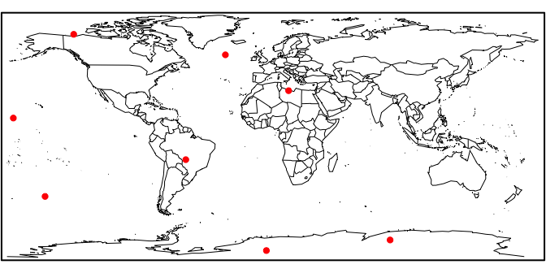

```r
require(maps)
map(mar=rep(0.1,4))
points(geo.coords,pch=19,col="red")
box(lwd=2)
```

Note that having geographic sampling coordinates for each sample is not a requirement! If, for example, the genotyped samples were of unknown provenance, or if the user simply doesn’t want to specify the geographic coordinates associated with each sample, SpaceMix can still run. We discuss this point further in “Running a SpaceMix analysis” below.

# Running a SpaceMix analysis

A SpaceMix analysis entails running a Markov chain Monte Carlo (MCMC) algorithm. A thorough discussion of MCMC is beyond the scope of this vignette. Interested users should check out Gilks *et al.* (1996) [^1], or another intro to MCMC.

The function `run.spacemix.analysis` runs the SpaceMix analysis. This vignette is designed to be used *in tandem with* the documentation for that function, which can be viewed using `help(run.spacemix.analysis)`. Users may find it helpful to have the vignette open alongisde the help documentation.

A SpaceMix analysis has two components:

1. First, the function runs a user-specified number of “fast runs,” (specified using the `n.fast.reps` option in `run.spacemix.analysis`). These are short MCMC runs designed to do preliminary explorations of the parameter space and help the subsequent analyses. Their output is put into “fast_run” directories, which are numbered sequentially. These preliminary analyses are not necessary (users may go straight to the “Long Run” by specifying `n.fast.reps=0`), but they tend to help the longer run mix and converge better.
2. Second, a “Long Run” starts from the location in parameter space at the last iteration of the best fast run (designated the “Best Run”). The output of the “Long Run” MCMC is put into a “Long Run” directory.

Users must specify the number of generations for both the “fast runs” (`fast.MCMC.ngen`) and the “Long Run” (`ngen`), as well as the frequency with which the “Long Run” chain is sampled (`samplefreq`).

## Model options

SpaceMix’s inference algorithm may be used to estimate the parameters of any of the following models:

1. population locations are fixed, and they do not draw any admixture;
2. population locations are estimated, but not admixture;
3. populations may draw admixture, but their own locations are fixed; or
4. population locations and admixture are both estimated.

Although we anticipate most empirical researchers will be interested in the joint inference of a geogenetic map with admixture (Model 4), we have presented these models separately, as we believe each have their own utility. Model 1 and Model 3 can each be used to infer landscapes of allele frequencies, upon which genotyped individuals can be probabilistically placed, following Wasser *et al.* (2004) [^2]. This application may be useful to determine the geographic origin of potentially contraband biological samples (e.g., ivory), or the most likely source of museum specimens missing sampling metadata. Model 3 has the potential to improve the performance of these spatial assignment methods over Model 1, as the inclusion of admixture in the model may allow for more accurate inference of allele frequency surfaces.  
Model 2 directly parallels Principal Component Analysis, and could also be used in a model comparison framework with Model 4 to formally test for the presence of admixture in the sampled dataset.

## Spatial priors

Under the assumption that the data show a pattern of Isolation by Distance (IBD), our prior belief is that the geogenetic map of the samples will be similar to the geographic map of the samples. Following from this belief, the default model is to place a prior on the geogenetic location parameter for each sample that is centered on the geographic sampling location (i.e., long and lat) of that sample. The variance of that prior may be specified by the user (a higher variance decreases the strength of the prior).

To parameterize these priors, the user must specify a vector of longitude coordinates (`spatial.prior.X.coordinates`) and latitude coordinates (`spatial.prior.Y.coordinates`), both of length equal to the number of samples in the dataset.

As mentioned above, if the user does not have, or does not wish to specify, geographic coordinates for all or some of the samples in the dataset, she may use randomly or arbitrarily chosen longitude and latitude coordinates instead.

Below, we give examples of how to run a SpaceMix analysis under different scenarios.

```r
# EXAMPLE 1

# First, load data object
data(spacemix.example.dataset)

# Data option: allele counts and sample sizes
# Fast Model option: estimating geogenetic locations
# Long Model option: estimating geogenetic locations and
#                    admixture source locations
# Spatial priors: default variance,
#                   observed geographic sampling locations
run.spacemix.analysis(n.fast.reps = 10,
                        fast.MCMC.ngen = 1e5,
                        fast.model.option = "target",
                        long.model.option = "source_and_target",
                        data.type = "counts",
                        sample.frequencies=NULL,
                        mean.sample.sizes=NULL,
                        counts = spacemix.example.dataset$allele.counts,
                        sample.sizes = spacemix.example.dataset$sample.sizes,
                        sample.covariance=NULL,
                        target.spatial.prior.scale=NULL,
                        source.spatial.prior.scale=NULL,
                        spatial.prior.X.coordinates = spacemix.example.dataset$population.coordinates[,1],
                        spatial.prior.Y.coordinates = spacemix.example.dataset$population.coordinates[,2],
                        round.earth = FALSE,
                        long.run.initial.parameters=NULL,
                        k = nrow(spacemix.example.dataset$allele.counts),
                        loci = ncol(spacemix.example.dataset$sample.sizes),
                        ngen = 1e6,
                        printfreq = 1e2,
                        samplefreq = 1e3,
                        mixing.diagn.freq = 50,
                        savefreq = 1e5,
                        directory=NULL,
                        prefix = "example_run1")
```

The code block above specifies an analysis in which the user is running 10 initial fast runs, each for 100,000 MCMC iterations, using a model in which only geogenetic locations for the samples are being estimated. The user is specifying allele count and sample size data, and is using the true geographic sampling coordinates as the means of the spatial priors on geogenetic locations. The long MCMC analysis is being run for 1,000,000 iterations, sampling the chain every 1,000 iterations, printing updates (sampled iteration and posterior probability) to the screen every 100 iterations, and saving the model output every 100,000 iterations. In addition, the long run is estimating both geogenetic sampling locations and admixture source locations, and distances between locations are being estimated on a flat plane, rather than on a globe.

```r
# EXAMPLE 2

# First, load data object
data(spacemix.example.dataset)

# Next, make allele frequencies and mean sample size objects
allele.frequencies <- spacemix.example.dataset$allele.counts / spacemix.example.dataset$sample.sizes
tmp.sample.sizes <- spacemix.example.dataset$sample.sizes
tmp.sample.sizes[which(spacemix.example.dataset$sample.sizes == 0)] <- NA
mean.sample.sizes <- rowMeans(tmp.sample.sizes,na.rm=TRUE)

# Data option: allele frequencies and mean sample sizes
# Fast Model option: estimating geogenetic locations and
#                    admixture source locations
# Long Model option: estimating geogenetic locations and
#                    admixture source locations
# Spatial priors: default variance,
#                   random locations for sampling coordinates
run.spacemix.analysis(n.fast.reps = 10,
                        fast.MCMC.ngen = 1e5,
                        fast.model.option = "source_and_target",
                        long.model.option = "source_and_target",
                        data.type = "sample.frequencies",
                        sample.frequencies = allele.frequencies,
                        mean.sample.sizes = mean.sample.sizes,
                        counts = NULL,
                        sample.sizes = NULL,
                        sample.covariance=NULL,
                        target.spatial.prior.scale=NULL,
                        source.spatial.prior.scale=NULL,
                        spatial.prior.X.coordinates = runif(nrow(spacemix.example.dataset$allele.counts),-180,180),
                        spatial.prior.Y.coordinates = runif(nrow(spacemix.example.dataset$allele.counts),-90,90),
                        round.earth = TRUE,
                        long.run.initial.parameters=NULL,
                        k = nrow(allele.frequencies),
                        loci = ncol(allele.frequencies),
                        ngen = 1e6,
                        printfreq = 1e2,
                        samplefreq = 1e3,
                        mixing.diagn.freq = 50,
                        savefreq = 1e5,
                        directory=NULL,
                        prefix = "example_run2")
```

The code block above specifies an analysis in which the user is running 10 initial fast runs, each for 100,000 MCMC iterations, using a model in which both geogenetic locations for the samples and admixture source locations are being estimated. The user is specifying frequency and mean sample size data, and is using randomly generated coordinates as the means of the spatial priors on geogenetic locations. The long MCMC analysis is being run for 1,000,000 iterations, sampling the chain every 1,000 iterations, printing updates (sampled iteration and posterior probability) to the screen every 100 iterations, and saving the model output every 100,000 iterations. In addition, the long run is estimating both geogenetic sampling locations and admixture source locations, and distances between locations are being estimated on a globe.

```r
# EXAMPLE 3

# First, load data object
data(spacemix.example.dataset)

# Next, calculate sample covariance of normalized allele frequencies
allele.frequencies <- spacemix.example.dataset$allele.counts / spacemix.example.dataset$sample.sizes
normalized.allele.freqs <- normalize.allele.freqs(allele.frequencies,spacemix.example.dataset$sample.sizes)
sample.cov <- cov(t(normalized.allele.freqs))

# And get the mean sample sizes
tmp.sample.sizes <- spacemix.example.dataset$sample.sizes
tmp.sample.sizes[which(spacemix.example.dataset$sample.sizes == 0)] <- NA
mean.sample.sizes <- rowMeans(tmp.sample.sizes,na.rm=TRUE)

# Now, generate a list of parameter values at which to initiate
#   the analysis
initial.param.vals <- list("a0" = 0.9,
                     "a1" = 1.3,
                     "a2" = 0.5,
                     "population.coordinates" = rbind(spacemix.example.dataset$population.coordinates,
                                               matrix(runif(60,1,9),nrow=30,ncol=2)),
                     "admix.proportions" = rep(0.01,30),
                     "nugget" = rep(0.1,30))
# Data option: sample normalized allele frequency covariance
#               and mean sample sizes
# Fast Model option: no fast runs
# Long Model option: estimating geogenetic locations and
#                    admixture source locations
# Specifying initial parameter values for the long run
# Spatial priors: default variance,
#                   random locations for sampling coordinates
#
run.spacemix.analysis(n.fast.reps = 0,
                        fast.MCMC.ngen = 0,
                        fast.model.option = "source_and_target",
                        long.model.option = "source_and_target",
                        data.type = "sample.covariance",
                        sample.frequencies = NULL,
                        mean.sample.sizes = mean.sample.sizes,
                        counts = NULL,
                        sample.sizes = NULL,
                        sample.covariance = sample.cov,
                        target.spatial.prior.scale=NULL,
                        source.spatial.prior.scale=NULL,
                        spatial.prior.X.coordinates = runif(nrow(spacemix.example.dataset$allele.counts),-180,180),
                        spatial.prior.Y.coordinates = runif(nrow(spacemix.example.dataset$allele.counts),-90,90),
                        round.earth = TRUE,
                        long.run.initial.parameters = initial.param.vals,
                        k = nrow(sample.cov),
                        loci = ncol(allele.frequencies),
                        ngen = 1e6,
                        printfreq = 1e2,
                        samplefreq = 1e3,
                        mixing.diagn.freq = 50,
                        savefreq = 5e4,
                        directory=NULL,
                        prefix = "example_run3")
```

# Visualizing results

Below, we cover three aspects of visualizing the results of a SpaceMix analysis: MCMC diagnosis, geogenetic map-making, and assessing model adequacy.

## Evaluating MCMC performance As noted above, a thorough discussion of MCMC inference methods is beyond the scope of this vignette. However, we briefly present some graphical tools for assessing MCMC performance below, along with a short discussion of what users should keep an eye out for in their runs.

### Trace plots

A trace plot is a basic visual tool for assessing MCMC mixing. If the chain is mixing well, the trace plot will resemble a “fuzzy caterpillar.” If the trace plot has not plateaued, it is an indication that the chain has not converged on the stationary posterior distribution, and must be run longer. If the trace plot of a parameter exhibits high autocorrelation, the user may wish to “thin” the chain by decreasing the frequency with which the chain is sampled (option `samplefreq` in `run.spacemix.analysis`). If the chain appears to be bouncing between areas of “fuzzy caterpillar-dom,” it may be an indication of a multi-modal likelihood surface. Below, we show some example trace plots from a SpaceMix analysis:

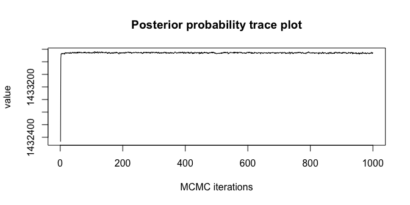

```r
# First, load the example data object
data(ex.output)

# Trace plot of posterior probability over the MCMC
plot(ex.output$Prob,xlab="MCMC iterations",ylab="value",
    main="Posterior probability trace plot",type='l')
```

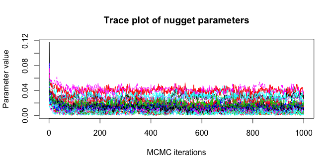

```r
# Trace plots of alpha parameters of the spatial covariance function
matplot(t(ex.output$nugget),type='l',
            xlab="MCMC iterations",ylab="Parameter value",
            main="Trace plot of nugget parameters")
```

### Joint marginal plots

Visualizations of the joint marginal distributions allow users to assess how well the MCMC is mixing, and potentially diagnose instances of non-identifiability in the model. Strong linear trends in the joint marginal, or visible “ridges” in the likelihood surface, may be indicative of parameter non-identifiability, in which multiple combinations of values of these two parameters provide equally reasonable fits to the data.

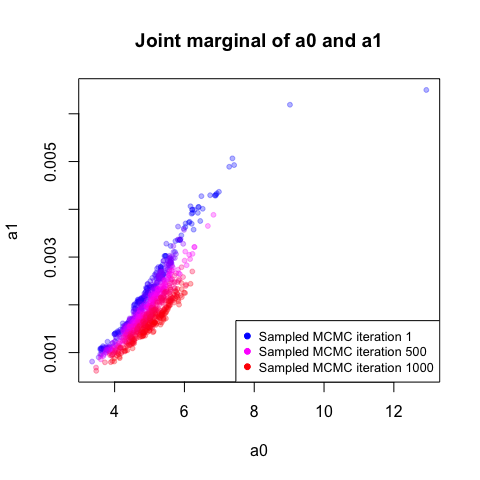

```r
# Joint marginal plot of a0 and a1
#   colored by where in the MCMC these
#   parameters took their values
plot(ex.output$a0,ex.output$a1,xlab="a0",ylab="a1",
    main="Joint marginal of a0 and a1",pch=20,
    col=adjustcolor(rainbow(1000,start=4/6,end=6/6),0.3))
legend(x="bottomright",pch=19,cex=0.8,
        col=rainbow(1000,start=4/6,end=6/6)[c(1,500,1000)],
        legend=c("Sampled MCMC iteration 1",
                 "Sampled MCMC iteration 500",
                 "Sampled MCMC iteration 1000"))
```

### Acceptance rate plots

SpaceMix implments an adaptive MCMC, in which the size of the proposed moves on each parameter is a function of the acceptance rate for that parameter over a sliding window (specified by `mixing.diagn.freq` in `run.spacemix.analysis`). SpaceMix is aiming for an acceptance rate of 44%; higher and lower values may decrease the efficiency of the MCMC and potentially increase the autocorrelation between samples. If the acceptance rate has not plateaued by the end of an analysis, it may be an indication that the chain is still “going somewhere” in parameter space, and the user may wish to perform subsequent analyses.

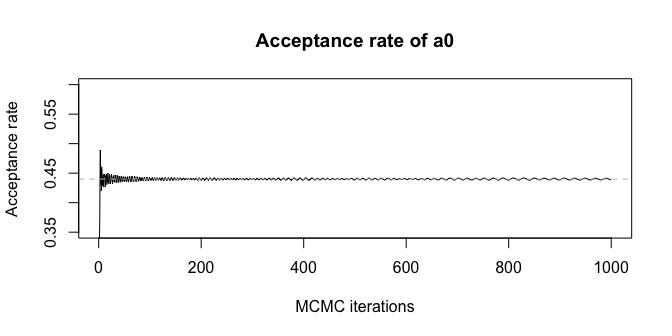

```r
# First, load the example data object
data(ex.output)

# Acceptance rate of a0 over the course of the
#   MCMC analysis
plot(ex.output$accept_rates$a0_accept_rate,
        xlab="MCMC iterations",ylab="Acceptance rate",
        main="Acceptance rate of a0",type='l',
        ylim=c(0.35,0.6))
    abline(h=0.44,col="gray",lty=2)
```

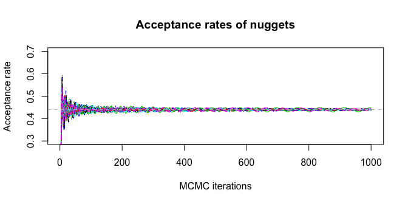

```r
# Acceptance rates of nugget parameters over the
#   course of the MCMC analysis
matplot(t(ex.output$accept_rates$nugget_accept_rate),
            xlab="MCMC iterations",ylab="Acceptance rate",
            main="Acceptance rates of nuggets",type='l',
            ylim=c(0.3,0.7))
    abline(h=0.44,col="gray",lty=2)
```

### Evaluating model adequacy

In addition to evaluating MCMC performance, it is also important to evaluate model adequacy, the ability of the model to describe the data. There are many ways to do this; below we outline two quick approaches for visually assessing model adequacy.

```r
# first, load the standardized (mean-centered and normalized)
#   allele frequency data object.  This object, which is the
#   "MCN.frequencies.list" (Mean Centered and Normalized) is
#   saved in the Long Run directory, and is generated if the
#   user has specified either allele count or allele frequeny
#   data.
#   Note that it is not generated if the user has specified the
#   sample covariance.

data(MCN.frequencies.list.RData)
```

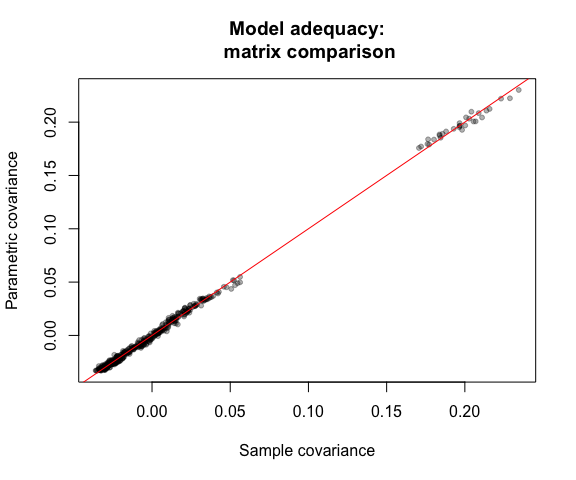

```r
# Now, calculate the sample covariance from the mean centered
#   and normalized sample allele frequencies.
    sample.covariance <- cov(t(MCN.frequencies.list$mean.centered.normalized.sample.frequencies),
                                use="pairwise.complete.obs")

# Next, load the example SpaceMix output object
data(ex.output)

# Create a matrix that will perform a mean-centering
#   on the parametric covariance matrix
# Then, mean-center the parametric ovariance matrix.
    k <- nrow(MCN.frequencies.list$mean.centered.normalized.sample.frequencies)
    MC.matrix <- diag(k) - matrix(1/ex.output$last.params$inv.mean.sample.sizes /
                                    (sum(1/ex.output$last.params$inv.mean.sample.sizes)),
                                        nrow=k,ncol=k,byrow=TRUE)

    MC.parametric.covariance <- (MC.matrix) %*%
                                    ex.output$last.params$admixed.covariance %*%
                                    t(MC.matrix)

# Finally, compare the sample covariance to the parametric
#   covariance.  Ideally, there will be a very tight correspondence
#   between the data and the model.  If there is not, it may
#   be an indication either that the MCMC has not converged on
#   the stationary distribution or that the process that generated
#   the data is only poorly approximated by SpaceMix's model.

# The sample and parametric covariances can be plotted
#   against each other (if model fit is good they should
#   fall on the x=y red line)
index.matrix <- upper.tri(sample.covariance,diag=TRUE)
plot(sample.covariance[index.matrix],
    MC.parametric.covariance[index.matrix],
    col=adjustcolor("black",0.3),pch=20,
    xlab="Sample covariance",
    ylab="Parametric covariance",
    main="Model adequacy:\n matrix comparison")
    abline(0,1,col="red")
```

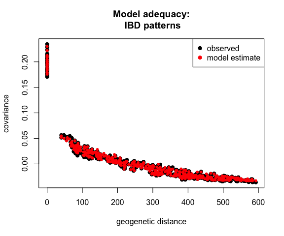

```r
# Or the patterns of decay of covariance with
#   geographic distance can be compared between
#   the data and the model.
plot(ex.output$last.params$D[1:k,1:k][index.matrix],
        sample.covariance[index.matrix],
        pch=19,col="black",
        xlab="geogenetic distance",
        ylab="covariance",
        main="Model adequacy:\n IBD patterns")
        points(ex.output$last.params$D[1:k,1:k][index.matrix],
                MC.parametric.covariance[index.matrix],col="red",pch=20)
        legend(x="topright",pch=19,col=c(1,2),
                legend=c("observed","model estimate"))
```

```r
# note, this can also be applied over the posterior distribution
#   of parametric covariances, to visualize fit over the whole MCMC
```

## Making geogenetic maps

The primary output of a SpaceMix analysis is a geogenetic map, in which distances between sample locations reflect genetic, rather than geographic. These maps are designed to be intuitive, but also information-rich, and users may wish to find their own balance between information density and intuitiveness. Below, we show examples using a few helper functions included in the SpaceMix package. However, for users wishing to design their own visualization functions, a good starting point may be to examine the code of the functions used below.

The first step in making a geogenetic map is to generate a list object that can be used or reference later for easy visualization of SpaceMix results.

Because this function takes as its argument the path of the output file produced in a SpaceMix analysis, the code immediately below is not evaluated, and is included solely as an example.

```r
# Say that we have 30 samples from a regular grid
population.coordinates <- matrix(c(1,1,1,1,1,3,3,3,3,3,5,5,5,5,5,
                                    7,7,7,7,7,9,9,9,9,9,11,11,11,11,11,
                                    1,3,5,7,9,1,3,5,7,9,1,3,5,7,9,
                                    1,3,5,7,9,1,3,5,7,9,1,3,5,7,9),
                                nrow=30,ncol=2)
# Now generate a vector of sample names
sample.names <- unlist(lapply(1:30,function(i){sprintf("Sample_%s",i)}))

# And generate a vector of sample colors
sample.colors <- rainbow(n=30,start=4/6,end=6/6)[as.numeric(cut(population.coordinates[,1],30))]

# And now generate a sample map list using a 95%
#   credible interval on parameter estimates without
#   `burning' (i.e., discarding) any sampled iterations
#   of the MCMC.
example.spacemix.map.list <- make.spacemix.map.list(MCMC.output.file = "~/MY_PATH/example_MCMC_output1.Robj",
                                geographic.locations = population.coordinates,
                                name.vector = sample.names,
                                color.vector = sample.colors,
                                quantile=0.95,
                                burnin=0)
```

Now, using this list, we can make a geogenetic map

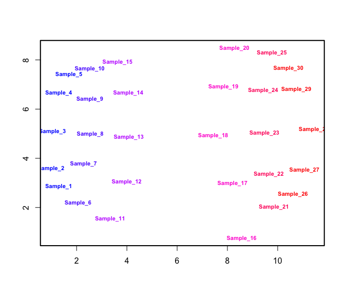

```r
# load the example map list generated using the code
#   block above (with a real path for the output object
data(example.spacemix.map.list)

# Now we generate a map of the output showing sample names
#   at the locations of the maximum a posteriori (MAP)
#   geogenetic location parameter estimates
make.spacemix.map(spacemix.map.list = example.spacemix.map.list,
                text=TRUE,
                ellipses=FALSE,
                source.option=FALSE)
```

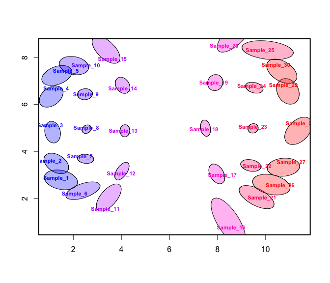

```r
# Now, to visualize uncertainty in location parameter estimates,
#   we generate a map of the output showing 95% credible
#   ellipses for the geogenetic locations of all samples
#   and plotting sample names at the locations of the
#   maximum a posteriori (MAP) geogenetic location parameter
#   estimates
make.spacemix.map(spacemix.map.list = example.spacemix.map.list,
                text=TRUE,
                ellipses=TRUE,
                source.option=FALSE)
```

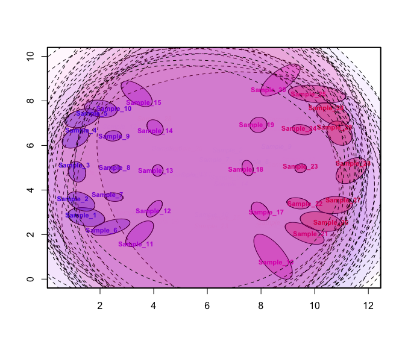

```r
# Notice that the figure is cut off a little bit,
#   so we can tweak that to make it nicer
make.spacemix.map(example.spacemix.map.list,
                source.option=TRUE,
                text=TRUE,xlim=c(0.5,12),ylim=c(0,10))

# Now, to visualize the sources of admixture, we can plot
#   those as well
make.spacemix.map(example.spacemix.map.list,
                source.option=TRUE,
                text=TRUE,xlim=c(0.5,12),ylim=c(0,10))
```

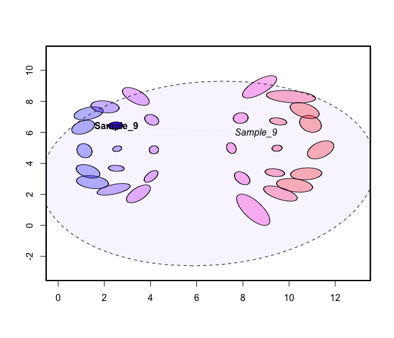

```r
# This map looks like a bit of a mess, because even though
#   most samples are drawing negligible amounts of admixture,
#   they're all drawing SOME admixture, so they all get plotted
#   and the output is difficult to visually interpret.
#
# To do a better job, we can be selective about which admixutre
#   sources we highlight using the `query.spacemix.map` function
make.spacemix.map(example.spacemix.map.list,
                source.option=FALSE,
                text=FALSE,xlim=c(0,13),ylim=c(-3,11))

# Now, we just highlight the geogenetic location for Sample 9,
#   as well as the location of its source of admixture, which
#   is plotted in italics with a dashed border around its 95%
#   credible ellipse.
query.spacemix.map(focal.pops=c("Sample_9"),
                        spacemix.map.list = example.spacemix.map.list,
                        ellipses=TRUE,source.option=TRUE)
```

## Contact

Hopefully you found this vignette helpful! If you have further questions you can contact gbradburd@ucdavis.edu. However, before you email, please check to make sure that the answer to your question is not in this vignette or the help files for the SpaceMix package.

[^1]: Gilks, W.R. and Richardson, S. and Spiegelhalter, D.J. Markov Chain Monte Carlo in Practice. Chapman & Hall/CRC. 1996.
[^2]: Samuel K Wasser, Andrew M Shedlock, Kenine Comstock, Elaine Ostrander, Benezeth Mutayoba, and Matthew Stephens. Assigning African elephant DNA to geographic region of origin: Applications to the ivory trade. PNAS, 101(41): 14847–52, 2004.